# Predictive Modeling Group Assignment (Group 12)

Problem statement:

Simmons Catalogue (Adapted from Anderson, Sweeney, and Williams)

Simmons’ catalogs are expensive and Simmons would like to send them to only those customers who have the highest probability of making a $200 purchase using the discount coupon included in the catalog. Simmons’ management thinks that annual spending at Simmons Stores and whether a customer has a Simmons credit card are two variables that might be helpful in predicting whether a customer who receives the catalog will use the coupon to make a $200 purchase.

Simmons conducted a study by sending out 100 catalogs, 50 to customers who have a Simmons credit card and 50 to customers who do not have the card. At the end of the test period, Simmons noted for each of the 100 customers: 1) the amount the customer spent last year at Simmons, 2) whether the customer had a Simmons credit card, and 3) whether the customer made a $200 purchase. The data file that contains the information is in Logit-Simmons.xls Develop a logistic regression model, obtain the output and interpret the results

Solution:

Let us start with imporing Libraries

```r
library(caret)
```

```r
library(ggplot2)
library(Information)
library(caTools)
library(stringr)
library(car)
library(ROCR)
library(MASS)
library(gmodels)
library(dummies)
library(Hmisc)
getwd()
```

```
## [1] "C:/Users/vbhagat/Documents/BA/GreatLakes/Predictive Modelling/GA"
```

```r
Rawdata <- read.csv("Logit-Simmons.csv")
summary(Rawdata)
```

```
##     Customer         Spending          Card        Purchase
##  Min.   :  1.00   Min.   :1.058   Min.   :0.0   Min.   :0.0
##  1st Qu.: 25.75   1st Qu.:2.059   1st Qu.:0.0   1st Qu.:0.0
##  Median : 50.50   Median :2.805   Median :0.5   Median :0.0
##  Mean   : 50.50   Mean   :3.334   Mean   :0.5   Mean   :0.4
##  3rd Qu.: 75.25   3rd Qu.:4.468   3rd Qu.:1.0   3rd Qu.:1.0
##  Max.   :100.00   Max.   :7.076   Max.   :1.0   Max.   :1.0
##     SpendCat
##  Min.   :0.00
##  1st Qu.:0.00
##  Median :0.00
##  Mean   :0.46
##  3rd Qu.:1.00
##  Max.   :1.00
```

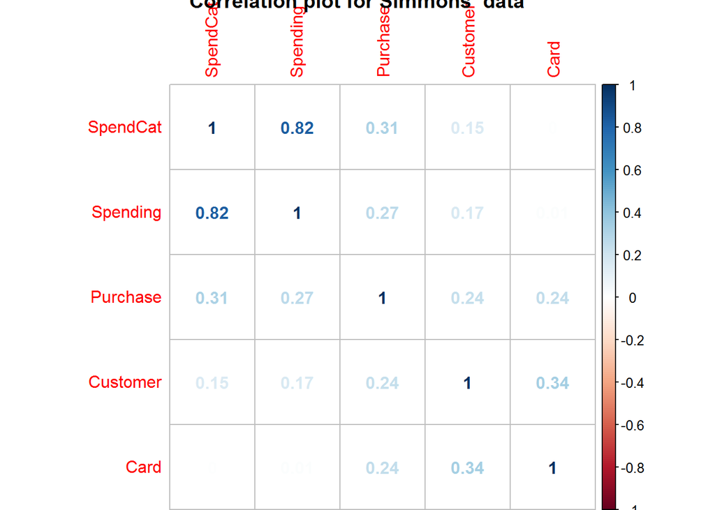

```r
library(corrplot)
corrplot(cor(Rawdata),method = "number",title = "Correlation plot for Simmons  data",order = "FPC")
```

SpendCat and Spending are higly correlated. So for model building prpose, we will exclude SpendCat variable. Reason for choosing SpendCat is that very less information is avaibale about .

Also Customer ID is just an index and we will have to remove it from our observations.

```r
str(Rawdata)
```

```
## 'data.frame':    100 obs. of  5 variables:
##  $ Customer: int  1 2 3 4 5 6 7 8 9 10 ...
##  $ Spending: num  2.29 3.21 2.13 3.92 2.53 ...
##  $ Card    : int  1 1 1 0 1 0 0 0 1 0 ...
##  $ Purchase: int  0 0 0 0 0 1 0 0 1 0 ...
##  $ SpendCat: int  0 1 0 1 0 0 0 1 0 1 ...
```

Variable understanding:

Customer : Unique customer ID. Spending : amount the customer spent last year at Simmons, (this will be our x1) Card : whether the customer had a Simmons credit card(1=customer has card ; 0=customer do not have card) (this will be our x2) Purchase : whether the customer will use coupon to make $200 purcase (this will be our Y variable) SpendCat : Spending Cataloue

Let us convert Card and Purchase to categorical variables i.e. factors

```r
LogisticsData=Rawdata[,c(2,3,4)]
LogisticsData$Card=as.factor(LogisticsData$Card)
LogisticsData$Purchase=as.factor(LogisticsData$Purchase)

str(LogisticsData)
```

```
## 'data.frame':    100 obs. of  3 variables:
##  $ Spending: num  2.29 3.21 2.13 3.92 2.53 ...
##  $ Card    : Factor w/ 2 levels "0","1": 2 2 2 1 2 1 1 1 2 1 ...
##  $ Purchase: Factor w/ 2 levels "0","1": 1 1 1 1 1 2 1 1 2 1 ...
```

```r
summary(LogisticsData)
```

```
##     Spending     Card   Purchase
##  Min.   :1.058   0:50   0:60
##  1st Qu.:2.059   1:50   1:40
##  Median :2.805
##  Mean   :3.334
##  3rd Qu.:4.468
##  Max.   :7.076
```

```r
print(LogisticsData)
```

```
##     Spending Card Purchase
## 1      2.291    1        0
## 2      3.215    1        0
## 3      2.135    1        0
## 4      3.924    0        0
## 5      2.528    1        0
## 6      2.473    0        1
## 7      2.384    0        0
## 8      7.076    0        0
## 9      1.182    1        1
## 10     3.345    0        0
## 11     2.140    1        0
## 12     3.255    0        1
## 13     1.512    0        0
## 14     2.148    0        1
```

[output cut: 86 more lines]

Let us check if there is any missing value

```r
anyNA(LogisticsData)
```

```
## [1] FALSE
```

So there is not null or missing value in the dataset

```r
CrossTable(LogisticsData$Card)
```

```
##
##
##    Cell Contents
## |-------------------------|
## |                       N |
## |         N / Table Total |
## |-------------------------|
##
##
## Total Observations in Table:  100
##
##
##           |         0 |         1 |
##           |-----------|-----------|
##           |        50 |        50 |
##           |     0.500 |     0.500 |
##           |-----------|-----------|
##
##
##
##
```

```r
CrossTable(LogisticsData$Purchase)
```

```
##
##
##    Cell Contents
## |-------------------------|
## |                       N |
## |         N / Table Total |
## |-------------------------|
##
##
## Total Observations in Table:  100
##
##
##           |         0 |         1 |
##           |-----------|-----------|
##           |        60 |        40 |
##           |     0.600 |     0.400 |
##           |-----------|-----------|
##
##
##
##
```

```r
#CrossTable(LogisticsData$SpendCat)
```

Check For Missing Values in the Data set

```r
sum(is.na(LogisticsData))
```

```
## [1] 0
```

Let us now find if there is any outlier

```r
quantile(LogisticsData$Spending, c(0.05,0.1,0.2,0.3,0.4,0.50,0.6,0.7,0.8,0.9,0.95,0.99,1))
```

```
##     5%    10%    20%    30%    40%    50%    60%    70%    80%    90%
## 1.1376 1.5011 1.9662 2.1385 2.3524 2.8055 3.3180 3.9447 5.0714 6.2015
##    95%    99%   100%
## 6.7370 7.0760 7.0760
```

From above quantiles, we can say that there is no outlier present in In Spending variable.

Remaining two variables i.e. Card and Purchase are categorical variables. so we don’t have to check for outlier for thosre variables.

Now let us create dummy variables for categories of categorical variable.

```r
#LogisticsDataDum = dummy.data.frame(LogisticsData,names = c("Card","Purchase"),sep="_")
LogisticsDataDum = dummy.data.frame(LogisticsData,names = c("Card"),sep="_")




str(LogisticsDataDum)
```

```
## 'data.frame':    100 obs. of  4 variables:
##  $ Spending: num  2.29 3.21 2.13 3.92 2.53 ...
##  $ Card_0  : int  0 0 0 1 0 1 1 1 0 1 ...
##  $ Card_1  : int  1 1 1 0 1 0 0 0 1 0 ...
##  $ Purchase: Factor w/ 2 levels "0","1": 1 1 1 1 1 2 1 1 2 1 ...
##  - attr(*, "dummies")=List of 1
##   ..$ Card: int  2 3
```

```r
print(LogisticsDataDum)
```

```
##     Spending Card_0 Card_1 Purchase
## 1      2.291      0      1        0
## 2      3.215      0      1        0
## 3      2.135      0      1        0
## 4      3.924      1      0        0
## 5      2.528      0      1        0
## 6      2.473      1      0        1
## 7      2.384      1      0        0
## 8      7.076      1      0        0
## 9      1.182      0      1        1
## 10     3.345      1      0        0
## 11     2.140      0      1        0
## 12     3.255      1      0        1
## 13     1.512      1      0        0
## 14     2.148      1      0        1
```

[output cut: 86 more lines]

In a categorical variable, if there are n levels, then we will have to create n-1 dummy variables.

We will remove column “Customer”" as it is customer id which is not adding any value to our regression as of now

I am removing “SpendCat”" as there is no clear information about that variable given.

```r
LogisticsDataDum1=LogisticsDataDum[,-c(2)]
str(LogisticsDataDum1)
```

```
## 'data.frame':    100 obs. of  3 variables:
##  $ Spending: num  2.29 3.21 2.13 3.92 2.53 ...
##  $ Card_1  : int  1 1 1 0 1 0 0 0 1 0 ...
##  $ Purchase: Factor w/ 2 levels "0","1": 1 1 1 1 1 2 1 1 2 1 ...
```

```r
print(LogisticsDataDum1)
```

```
##     Spending Card_1 Purchase
## 1      2.291      1        0
## 2      3.215      1        0
## 3      2.135      1        0
## 4      3.924      0        0
## 5      2.528      1        0
## 6      2.473      0        1
## 7      2.384      0        0
## 8      7.076      0        0
## 9      1.182      1        1
## 10     3.345      0        0
## 11     2.140      1        0
## 12     3.255      0        1
## 13     1.512      0        0
## 14     2.148      0        1
```

[output cut: 86 more lines]

```r
# split
smp_size <- floor(0.7 * nrow(LogisticsDataDum1))
## set the seed to make your partition reproductible
set.seed(123)
train_ind <- sample(seq_len(nrow(LogisticsDataDum1)), size = smp_size)
train <- LogisticsDataDum1[train_ind, ]
test <- LogisticsDataDum1[-train_ind, ]
nrow(train)
```

```
## [1] 70
```

```r
nrow(test)
```

```
## [1] 30
```

```r
# Model with all variables
model1 <- glm(Purchase ~ ., data = train, family = binomial)
summary(model1)
```

```
##
## Call:
## glm(formula = Purchase ~ ., family = binomial, data = train)
##
## Deviance Residuals:
##     Min       1Q   Median       3Q      Max
## -1.8827  -0.9958  -0.5863   1.0179   1.7704
##
## Coefficients:
##             Estimate Std. Error z value Pr(>|z|)
## (Intercept)  -2.2115     0.6901  -3.205  0.00135 **
## Spending      0.4266     0.1552   2.749  0.00598 **
## Card_1        1.0658     0.5387   1.979  0.04787 *
## ---
## Signif. codes:  0 '***' 0.001 '**' 0.01 '*' 0.05 '.' 0.1 ' ' 1
##
## (Dispersion parameter for binomial family taken to be 1)
##
##     Null deviance: 96.812  on 69  degrees of freedom
## Residual deviance: 83.244  on 67  degrees of freedom
## AIC: 89.244
##
## Number of Fisher Scoring iterations: 4
```

We will use stepwise variable selection method to get best fit model

```r
# Stepwise selection of variables
best_model = step(model1,direction = "both")
```

```
## Start:  AIC=89.24
## Purchase ~ Spending + Card_1
##
##            Df Deviance    AIC
## <none>          83.244 89.244
## - Card_1    1   87.311 91.311
## - Spending  1   91.788 95.788
```

```r
summary(best_model)
```

```
##
## Call:
## glm(formula = Purchase ~ Spending + Card_1, family = binomial,
##     data = train)
##
## Deviance Residuals:
##     Min       1Q   Median       3Q      Max
## -1.8827  -0.9958  -0.5863   1.0179   1.7704
##
## Coefficients:
##             Estimate Std. Error z value Pr(>|z|)
## (Intercept)  -2.2115     0.6901  -3.205  0.00135 **
## Spending      0.4266     0.1552   2.749  0.00598 **
## Card_1        1.0658     0.5387   1.979  0.04787 *
## ---
## Signif. codes:  0 '***' 0.001 '**' 0.01 '*' 0.05 '.' 0.1 ' ' 1
##
## (Dispersion parameter for binomial family taken to be 1)
##
##     Null deviance: 96.812  on 69  degrees of freedom
## Residual deviance: 83.244  on 67  degrees of freedom
## AIC: 89.244
##
## Number of Fisher Scoring iterations: 4
```

```r
vif(model1)
```

```
## Spending   Card_1
## 1.003126 1.003126
```

```r
train$predTrain <- predict(model1, type = "response") # in-sample accuracy
#train$PredTrain <- PredTrain
print(train)
```

```
##    Spending Card_1 Purchase predTrain
## 29    1.677      0        0 0.1829975
## 79    3.255      1        1 0.5603938
## 41    3.253      0        0 0.3049350
## 86    6.737      1        1 0.8491630
## 91    1.130      1        0 0.3399123
## 5     2.528      1        0 0.4831687
## 50    4.004      1        1 0.6369743
## 83    2.372      1        0 0.4665764
## 51    1.068      1        1 0.3340038
## 42    1.839      0        0 0.1935562
## 87    6.486      1        1 0.8349308
## 98    6.073      0        0 0.5936318
## 60    3.318      1        1 0.5670030
## 94    6.073      1        1 0.8091990
```

[output cut: 56 more lines]

```r
table(train$Purchase, train$predTrain >= 0.5)
```

```
##
##     FALSE TRUE
##   0    28    9
##   1    13   20
```

Accuracy is :

```r
  #(37+11)/(37+5+14+11)
(28+20)/(28+20+12+9)
```

```
## [1] 0.6956522
```

```r
test$predTest <- predict(model1, newdata = test, type = "response") # out-sample accuracy

print(test)
```

```
##     Spending Card_1 Purchase  predTest
## 1      2.291      1        0 0.4579878
## 7      2.384      0        0 0.2324391
## 12     3.255      0        1 0.3051158
## 17     1.307      0        0 0.1605694
## 18     3.470      1        0 0.5828469
## 19     2.936      0        0 0.2770530
## 23     2.118      0        0 0.2128124
## 31     1.138      0        0 0.1510888
## 34     5.365      0        0 0.5192388
## 35     6.179      0        0 0.6044915
## 36     1.980      1        0 0.4252870
## 37     1.058      1        0 0.3330556
## 43     1.657      1        0 0.3920063
## 45     3.566      0        0 0.3339457
```

[output cut: 16 more lines]

```r
table(test$Purchase, test$predTest >= 0.5)
```

```
##
##     FALSE TRUE
##   0    18    5
##   1     6    1
```

Accuracy is :

```r
#(13+9)/(13+5+6+9)
(18+1)/(18+1+5+6)
```

```
## [1] 0.6333333
```

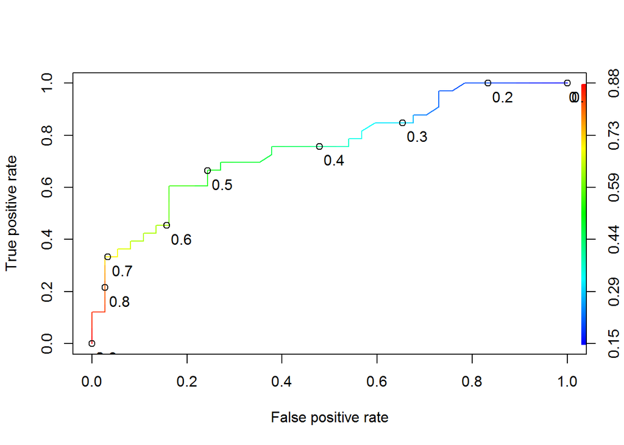

```r
# ROC Curve
library(ROCR)
ROCRpred <- prediction(train$predTrain, train$Purchase)
ROCRperf <- performance(ROCRpred, "tpr", "fpr")
plot(ROCRperf, colorize = TRUE, print.cutoffs.at = seq(0,1,0.1), text.adj = c(-0.2, 1.7))
```

```r
auc.tmp <- performance(ROCRpred,"auc");
auc <- as.numeric(auc.tmp@y.values)
auc
```

```
## [1] 0.7518428
```

```r
## C-statistic
library(Hmisc)

train$predicted_prob = predict(model1,  type = "response")
rcorr.cens(train$predicted_prob,train$Purchase)
```

```
##        C Index            Dxy           S.D.              n        missing
##      0.7518428      0.5036855      0.1153086     70.0000000      0.0000000
##     uncensored Relevant Pairs     Concordant      Uncertain
##     70.0000000   2442.0000000   1836.0000000      0.0000000
```

```r
test$predicted_prob = predict(model1, newdata = test,type = "response")
rcorr.cens(test$predicted_prob,test$Purchase)
```

```
##        C Index            Dxy           S.D.              n        missing
##      0.4223602     -0.1552795      0.2298590     30.0000000      0.0000000
##     uncensored Relevant Pairs     Concordant      Uncertain
##     30.0000000    322.0000000    136.0000000      0.0000000
```

```r
#KS-statistic

model_score <- prediction(train$predicted_prob,train$Purchase)

model_perf <- performance(model_score, "tpr", "fpr")

ks_table <- attr(model_perf, "y.values")[[1]] - (attr(model_perf, "x.values")[[1]])

ks = max(ks_table)

which(ks_table == ks)
```

```
## [1] 27
```

```r
ks
```

```
## [1] 0.4438984
```

```r
model_score_test <- prediction(test$predicted_prob,test$Purchase)

model_perf_test <- performance(model_score_test, "tpr", "fpr")

ks_table_test <- attr(model_perf_test, "y.values")[[1]] - (attr(model_perf_test, "x.values")[[1]])

ks1=max(ks_table_test)

which(ks_table_test == ks1)
```

```
## [1] 29
```

```r
ks1
```

```
## [1] 0.08695652
```

```r
# Information value
```